# Chess

GS

26/9/2021

```r
library(tidyverse)
library(patchwork)

theme_set(theme_bw())
```

General Info

This is a set of just over 20,000 games collected from a selection of users on the site Lichess.org, and how to collect more. I will also upload more games in the future as I collect them. This set contains the:

- Game ID;
- Rated (T/F);
- Start Time;
- End Time;
- Number of Turns;
- Game Status;
- Winner;
- Time Increment;
- White Player ID;
- White Player Rating;
- Black Player ID;
- Black Player Rating;
- All Moves in Standard Chess Notation;
- Opening Eco (Standardised Code for any given opening, list here);
- Opening Name;
- Opening Ply (Number of moves in the opening phase)

For each of these separate games from Lichess. I collected this data using the Lichess API, which enables collection of any given users game history. The difficult part was collecting usernames to use, however the API also enables dumping of all users in a Lichess team. There are several teams on Lichess with over 1,500 players, so this proved an effective way to get users to collect games from.

Possible Uses

Lots of information is contained within a single chess game, let alone a full dataset of multiple games. It is primarily a game of patterns, and data science is all about detecting patterns in data, which is why chess has been one of the most invested in areas of AI in the past. This dataset collects all of the information available from 20,000 games and presents it in a format that is easy to process for analysis of, for example, what allows a player to win as black or white, how much meta (out-of-game) factors affect a game, the relationship between openings and victory for black and white and more.

```r
games <- read_csv("games.csv")

#cleaning variables
chess <- games %>%
  select(rated, turns, victory_status, winner, white_rating, black_rating, moves, opening_eco, opening_name, opening_ply)
chess
```

```
# A tibble: 20,058 x 10
   rated turns victory_status winner white_rating black_rating moves opening_eco
   <lgl> <dbl> <chr>          <chr>         <dbl>        <dbl> <chr> <chr>
 1 FALSE    13 outoftime      white          1500         1191 d4 d~ D10
 2 TRUE     16 resign         black          1322         1261 d4 N~ B00
 3 TRUE     61 mate           white          1496         1500 e4 e~ C20
 4 TRUE     61 mate           white          1439         1454 d4 d~ D02
 5 TRUE     95 mate           white          1523         1469 e4 e~ C41
 6 FALSE     5 draw           draw           1250         1002 e4 c~ B27
 7 TRUE     33 resign         white          1520         1423 d4 d~ D00
 8 FALSE     9 resign         black          1413         2108 e4 N~ B00
 9 TRUE     66 resign         black          1439         1392 e4 e~ C50
10 TRUE    119 mate           white          1381         1209 e4 d~ B01
# ... with 20,048 more rows, and 2 more variables: opening_name <chr>,
#   opening_ply <dbl>
```

```r
chess <- chess %>%
  mutate(victory_status = as.factor(victory_status),
         winner = as.factor(winner),
         opening_eco = as.factor(opening_eco))

summary(chess)
```

```
   rated             turns          victory_status    winner
 Mode :logical   Min.   :  1.00   draw     :  906   black: 9107
 FALSE:3903      1st Qu.: 37.00   mate     : 6325   draw :  950
 TRUE :16155     Median : 55.00   outoftime: 1680   white:10001
                 Mean   : 60.47   resign   :11147
                 3rd Qu.: 79.00
                 Max.   :349.00

  white_rating   black_rating     moves            opening_eco
 Min.   : 784   Min.   : 789   Length:20058       A00    : 1007
 1st Qu.:1398   1st Qu.:1391   Class :character   C00    :  844
 Median :1567   Median :1562   Mode  :character   D00    :  739
 Mean   :1597   Mean   :1589                      B01    :  716
 3rd Qu.:1793   3rd Qu.:1784                      C41    :  691
 Max.   :2700   Max.   :2723                      C20    :  675
                                                  (Other):15386
 opening_name        opening_ply
 Length:20058       Min.   : 1.000
 Class :character   1st Qu.: 3.000
 Mode  :character   Median : 4.000
                    Mean   : 4.817
                    3rd Qu.: 6.000
                    Max.   :28.000
```

I filtered games with more than 4 turns

```r
chess <- chess %>%
  filter(turns > 4)
```

## EDA

### Turns

```r
# ggplot(chess, aes(turns)) +
#   geom_histogram(fill = "lightgray", color = "black") +
#   scale_x_log10()
#
# ggplot(chess, aes(turns)) +
#   geom_boxplot()

# 289 games with more than 150 moves
chess %>%
  filter(turns > 150) %>%
  count()
```

```
# A tibble: 1 x 1
      n
  <int>
1   289
```

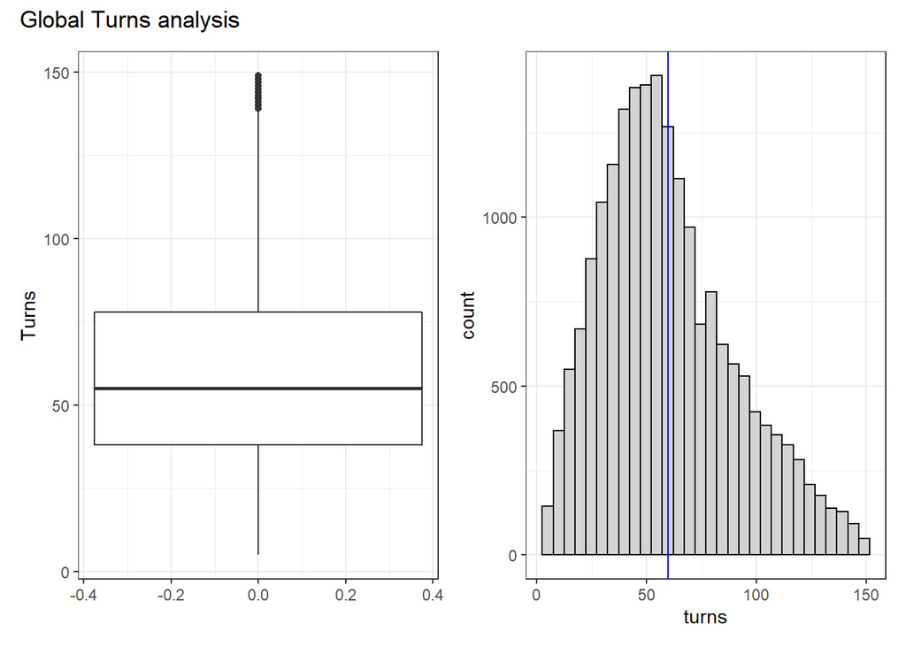

```r
chess <- chess %>%
  filter(turns < 150)


turns1 <- chess %>%
  ggplot(aes(turns)) +
  geom_boxplot() +
  coord_flip() +
  labs(x = "Turns")

turns2 <- chess %>%
  ggplot(aes(turns)) +
  geom_histogram(fill = "lightgray", color = "black") +
  geom_vline(xintercept = mean(chess$turns), color = "blue")

turns1 + turns2 + plot_annotation("Global Turns analysis")
```

### Victory status

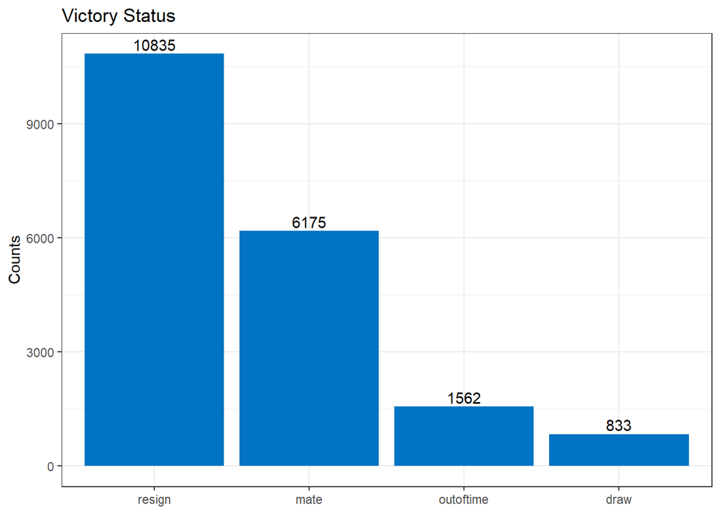

```r
chess %>%
  group_by(victory_status) %>%
  summarise(counts = n()) %>%
  ggplot(aes(x = reorder(victory_status, -counts), y = counts)) +
  geom_bar(stat = "identity", fill = "#0073C2FF") +
  geom_text(aes(label = counts), vjust = -.3) +
  labs(x = NULL, y = "Counts", title = "Victory Status")
```

### Winner

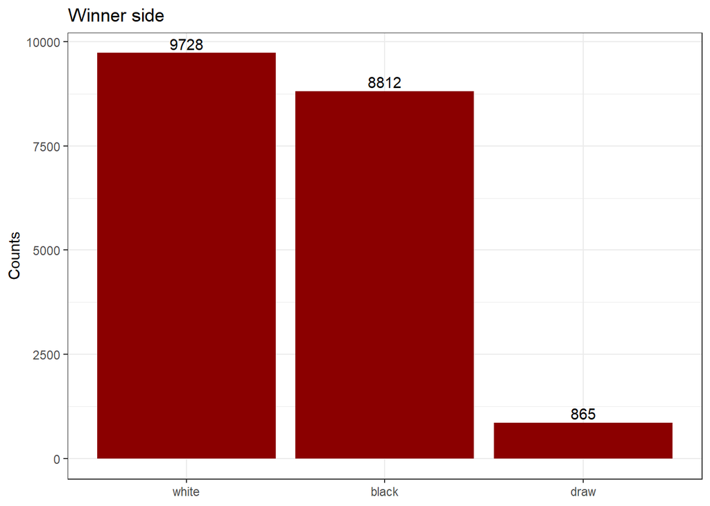

```r
chess %>%
  group_by(winner) %>%
  summarise(counts = n()) %>%
  ggplot(aes(x = reorder(winner, -counts), y = counts)) +
  geom_bar(stat = "identity", fill = "darkred") +
  geom_text(aes(label = counts), vjust = -.3) +
  labs(x = NULL, y = "Counts", title = "Winner side")
```

### Ratings

```r
t.test(chess$white_rating, chess$black_rating)
```

```
    Welch Two Sample t-test

data:  chess$white_rating and chess$black_rating
t = 2.7578, df = 38808, p-value = 0.005823
alternative hypothesis: true difference in means is not equal to 0
95 percent confidence interval:
  2.340041 13.838985
sample estimates:
mean of x mean of y
 1597.555  1589.465
```

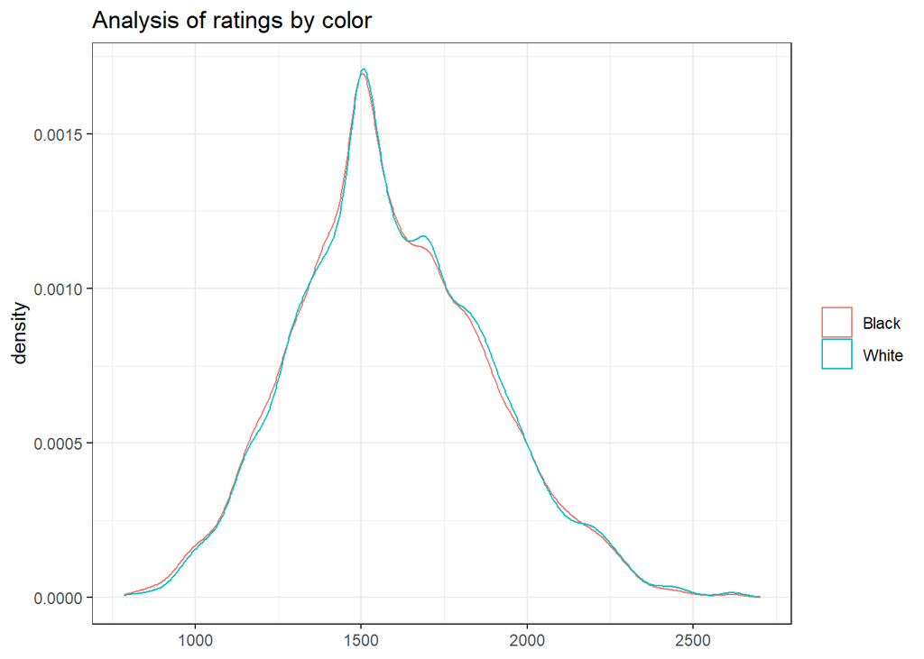

```r
chess %>%
  pivot_longer(cols = white_rating:black_rating, values_to = "value") %>%
  ggplot(aes(value, color = name)) +
  geom_density() +
  labs(x = NULL, color = NULL, title = "Analysis of ratings by color") +
  scale_color_discrete(labels = c("Black", "White"))
```

### Relation between ratings (white and black)

```r
with(chess, cor.test(white_rating, black_rating))
```

```
    Pearson's product-moment correlation

data:  white_rating and black_rating
t = 114.53, df = 19403, p-value < 2.2e-16
alternative hypothesis: true correlation is not equal to 0
95 percent confidence interval:
 0.6266304 0.6434215
sample estimates:
     cor
0.635101
```

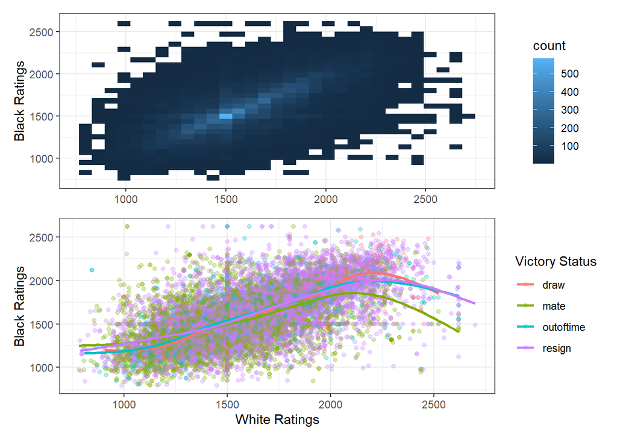

```r
rating1 <- chess %>%
  ggplot(aes(white_rating, black_rating)) +
  geom_bin2d() +
  labs(x = NULL, y = "Black Ratings")

rating2 <- chess %>%
  ggplot(aes(white_rating, black_rating, color = victory_status)) +
  geom_point(alpha = .3) +
  geom_smooth(se = F) +
  labs(x = "White Ratings", y = "Black Ratings", color = "Victory Status")

rating1 / rating2
```

### Number of Turns according to winning color

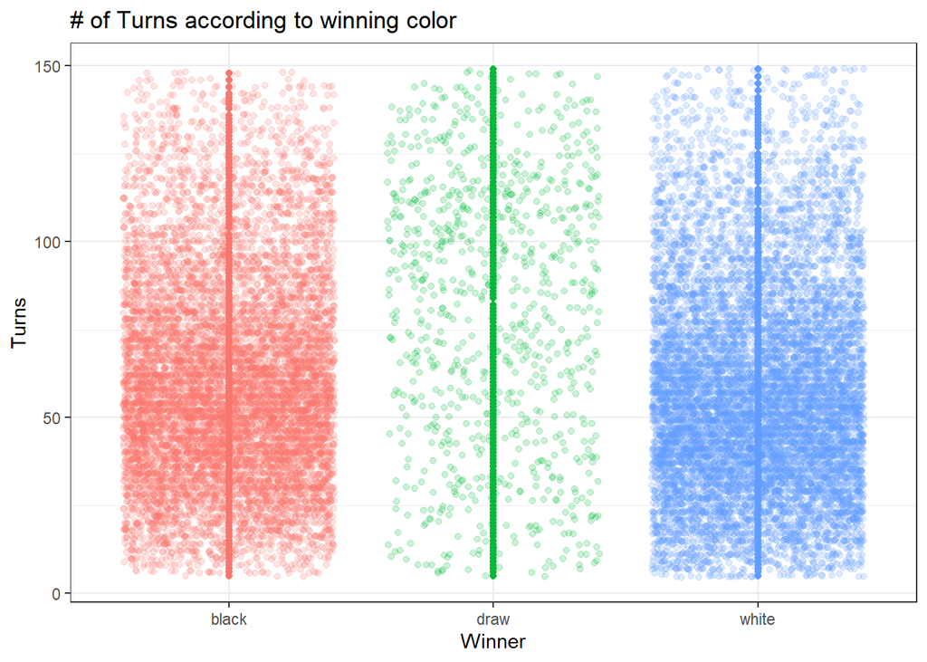

```r
ggplot(chess, aes(winner, turns, color = winner)) +
  geom_point() +
  geom_jitter(alpha = .2) +
  labs(x = "Winner", y = "Turns", title = "# of Turns according to winning color") +
  theme(legend.position = "none")
```

### Victory status according to numerb of turns and color

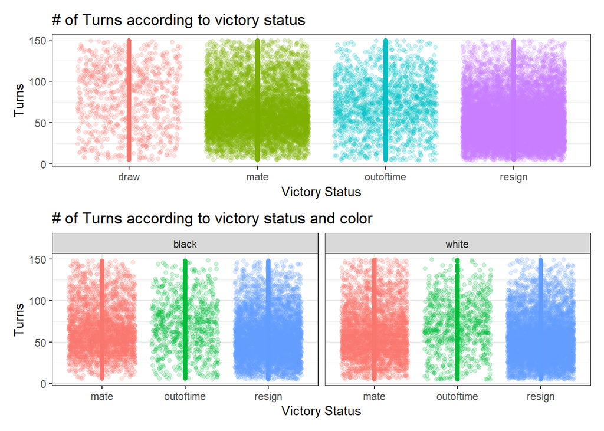

```r
vic1 <- ggplot(chess, aes(victory_status, turns, color = victory_status)) +
  geom_point() +
  geom_jitter(alpha = .2) +
  labs(x = "Victory Status", y = "Turns", title = "# of Turns according to victory status", color = NULL) +
  theme(legend.position = "none")

vic2 <- chess %>%
  filter(winner != "draw") %>%
  ggplot(aes(victory_status, turns, color = victory_status)) +
  geom_point() +
  geom_jitter(alpha = .2) +
  labs(x = "Victory Status", y = "Turns", title = "# of Turns according to victory status and color", color = NULL) +
  theme(legend.position = "none") +
  facet_wrap(.~ winner)

vic1 / vic2
```

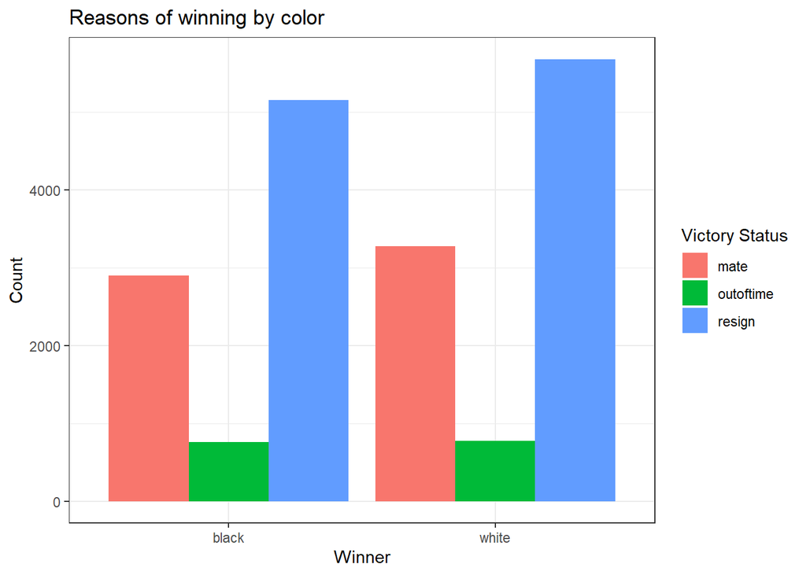

```r
chess %>%
  filter(winner != "draw") %>%
  ggplot(aes(winner, fill = victory_status)) +
  geom_bar(position = "dodge") +
  labs(x = "Winner", fill = "Victory Status", y = "Count", title = "Reasons of winning by color")
```

```r
chess
```

```
# A tibble: 19,405 x 10
   rated turns victory_status winner white_rating black_rating moves opening_eco
   <lgl> <dbl> <fct>          <fct>         <dbl>        <dbl> <chr> <fct>
 1 FALSE    13 outoftime      white          1500         1191 d4 d~ D10
 2 TRUE     16 resign         black          1322         1261 d4 N~ B00
 3 TRUE     61 mate           white          1496         1500 e4 e~ C20
 4 TRUE     61 mate           white          1439         1454 d4 d~ D02
 5 TRUE     95 mate           white          1523         1469 e4 e~ C41
 6 FALSE     5 draw           draw           1250         1002 e4 c~ B27
 7 TRUE     33 resign         white          1520         1423 d4 d~ D00
 8 FALSE     9 resign         black          1413         2108 e4 N~ B00
 9 TRUE     66 resign         black          1439         1392 e4 e~ C50
10 TRUE    119 mate           white          1381         1209 e4 d~ B01
# ... with 19,395 more rows, and 2 more variables: opening_name <chr>,
#   opening_ply <dbl>
```

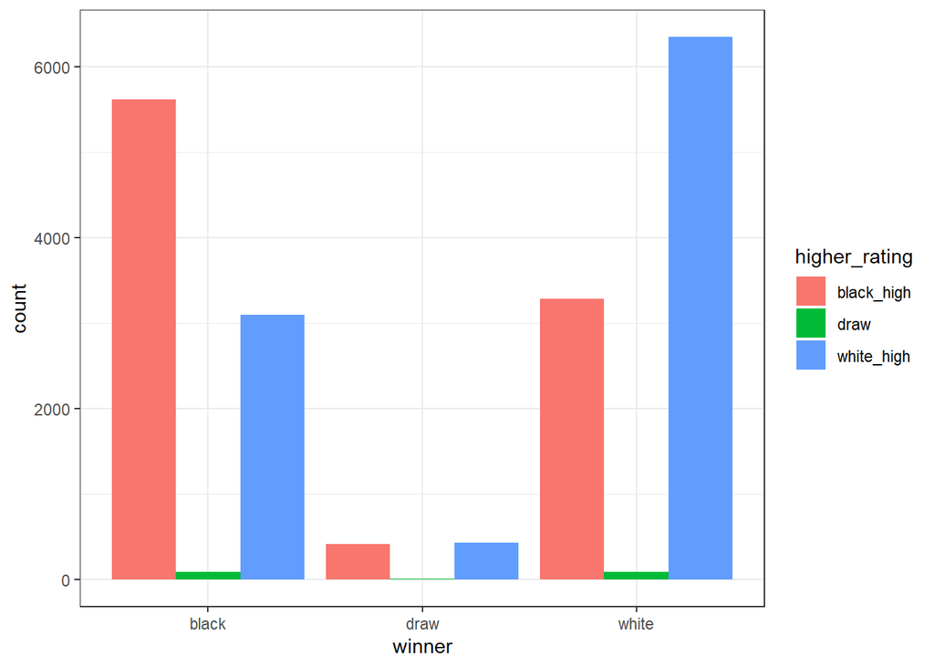

```r
draw <-
  chess %>%
  filter(white_rating == black_rating) %>%
  mutate(higher_rating = "draw")

# chess %>%
#   filter(white_rating != black_rating) %>%
#   mutate(higher_rating = if_else(white_rating > black_rating, "white_high", "black_high")) %>%
#   bind_rows(draw) %>%
#   ggplot(aes(winner, higher_rating, color = higher_rating)) +
#   geom_jitter()

chess %>%
  filter(white_rating != black_rating) %>%
  mutate(higher_rating = if_else(white_rating > black_rating, "white_high", "black_high")) %>%
  bind_rows(draw) %>%
  ggplot(aes(winner, fill = higher_rating)) +
  geom_bar(position = 'dodge')
```

```r
winner_by_rating <- chess %>%
  filter(white_rating != black_rating) %>%
  mutate(higher_rating = if_else(white_rating > black_rating, "white_high", "black_high")) %>%
  bind_rows(draw)

table(winner_by_rating$winner, winner_by_rating$higher_rating)
```

```
        black_high draw white_high
  black       5622   91       3099
  draw         417   13        435
  white       3288   91       6349
```

## Modeling

### Logistic Regression

```r
chess %>%
  filter(winner != "draw") %>%
  glm(winner ~ rated + turns + white_rating + black_rating, data = ., family = "binomial") %>%
  summary()
```

```
Call:
glm(formula = winner ~ rated + turns + white_rating + black_rating,
    family = "binomial", data = .)

Deviance Residuals:
    Min       1Q   Median       3Q      Max
-2.8148  -1.1106   0.4658   1.0628   2.9750

Coefficients:
               Estimate Std. Error z value Pr(>|z|)
(Intercept)   3.030e-01  1.041e-01   2.909  0.00362 **
ratedTRUE     1.482e-02  4.211e-02   0.352  0.72479
turns        -2.624e-03  5.450e-04  -4.814 1.48e-06 ***
white_rating  3.870e-03  9.164e-05  42.232  < 2e-16 ***
black_rating -3.915e-03  9.166e-05 -42.714  < 2e-16 ***
---
Signif. codes:  0 '***' 0.001 '**' 0.01 '*' 0.05 '.' 0.1 ' ' 1

(Dispersion parameter for binomial family taken to be 1)

    Null deviance: 25657  on 18539  degrees of freedom
Residual deviance: 22781  on 18535  degrees of freedom
AIC: 22791

Number of Fisher Scoring iterations: 4
```